# Chapter1. Quantmod

Quant Monkey

2019-08-21

### `Quantmod` package

```r
library(quantmod)
```

`quantmod` package 를 설치하고 주가를 불러오는 함수 `getSymbols()` 를 사용해보자. 주식코드번호에 코스피면 `.KS`,코스닥이면 `.KQ` 을 붙이면 된다. 최애주인 SK이노베이션으로 해보자.

```r
stock<-getSymbols(Symbols = "096770.KS",
                  from= "2017-04-03",
                  to = "2017-04-07",
                  auto.assign = FALSE)
stock
```

```
##            096770.KS.Open 096770.KS.High 096770.KS.Low 096770.KS.Close
## 2017-04-03         167000         168500        165500          166000
## 2017-04-04         165500         166000        161000          163000
## 2017-04-05         164500         165500        162500          163500
## 2017-04-06         163000         164500        161000          162500
## 2017-04-07         163500         165000        162500          164500
##            096770.KS.Volume 096770.KS.Adjusted
## 2017-04-03           121172           152436.8
## 2017-04-04           246259           149681.9
## 2017-04-05           174394           150141.0
## 2017-04-06           206571           149222.7
## 2017-04-07           174225           151059.3
```

시가(open),고가(high),저가(low),종가(close),거래량(volume),수정주가(adjusted) 데이터를 불러왔다.

수정주가는 종가 기준이며, 모든 가격을 수정가격으로 하고 싶을때는 `adjustOHLC` 함수를 사용하면 된다.

```r
stock<-adjustOHLC(stock,use.Adjusted = T)
stock
```

```
##            096770.KS.Open 096770.KS.High 096770.KS.Low 096770.KS.Close
## 2017-04-03       153355.1       154732.5      151977.6        152436.8
## 2017-04-04       151977.6       152436.8      147845.3        149681.9
## 2017-04-05       151059.3       151977.6      149222.7        150141.0
## 2017-04-06       149681.9       151059.3      147845.3        149222.7
## 2017-04-07       150141.0       151518.5      149222.7        151059.3
##            096770.KS.Volume 096770.KS.Adjusted
## 2017-04-03           121172           152436.8
## 2017-04-04           246259           149681.9
## 2017-04-05           174394           150141.0
## 2017-04-06           206571           149222.7
## 2017-04-07           174225           151059.3
```

```r
colnames(stock)<-c('open','high','low','close','volume','adjusted') #컬럼명 변경
```

간단히 그래프를 그려보기 앞서, `getSymbols` 불러온 데이터의 class 는 데이터 프레임이 아닌 `xts` 이다. 일반적인 `plot()` 그래프를 그릴수 있지만,

```r
class(stock)
```

```
## [1] "xts" "zoo"
```

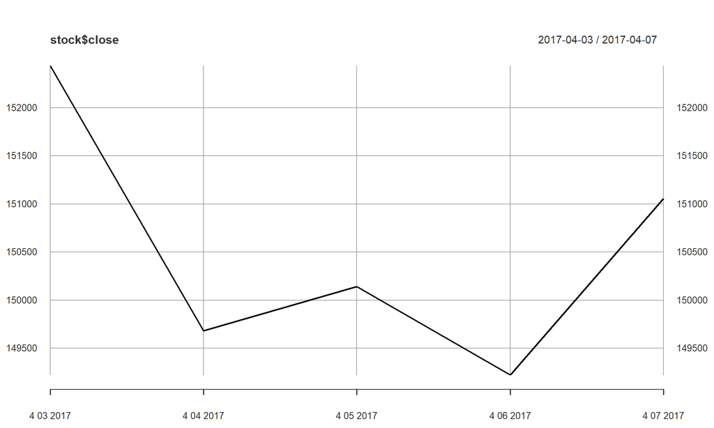

```r
plot(stock$close)
```

`chartSeries()` 함수로 눈에 익숙한 주식차트를 그릴수 있다. (데이터 형태가 `xts` 만 사용가능)

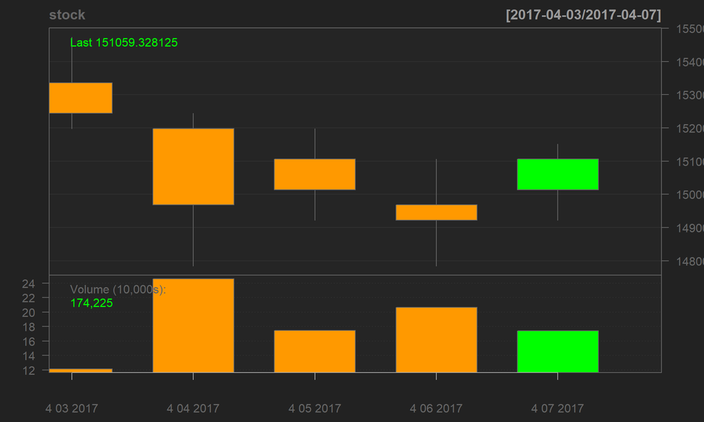

```r
chartSeries(stock)
```

색이 익숙하지 않다.

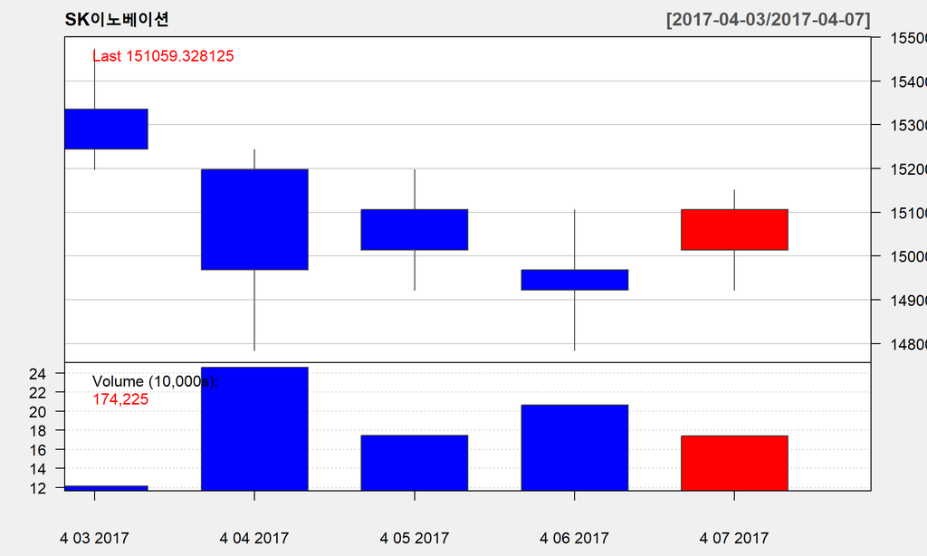

```r
chartSeries(stock,
            up.col='red',
            dn.col='blue',
            theme = 'white',
            name='SK이노베이션')
```

어설프지만, 어느정도 익숙한 차트가 그려졌다. 마지막으로 좀더 긴 기간의 데이터에 보조지표를 그려보자.

```r
stock2 <- getSymbols(Symbols = "096770.KS",
                  from= "2016-01-01",
                  to = "2016-12-31",
                  auto.assign = FALSE) #주가 데이터 불러오기
stock2<-adjustOHLC(stock2,use.Adjusted = T) #수정주가로 변환
colnames(stock2)<-c('open','high','low','close','volume','adjusted') # 컬럼명 변경
```

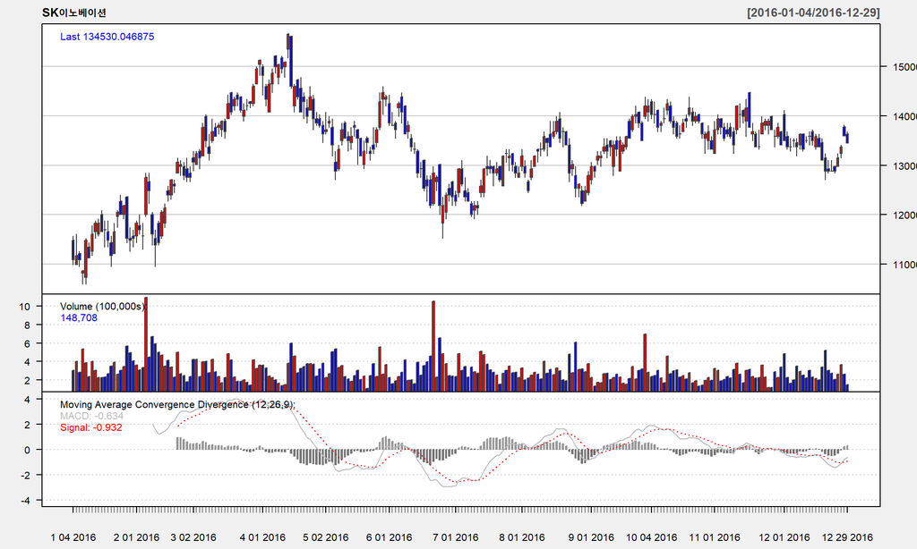

```r
addMACD() #MACD 추가
```

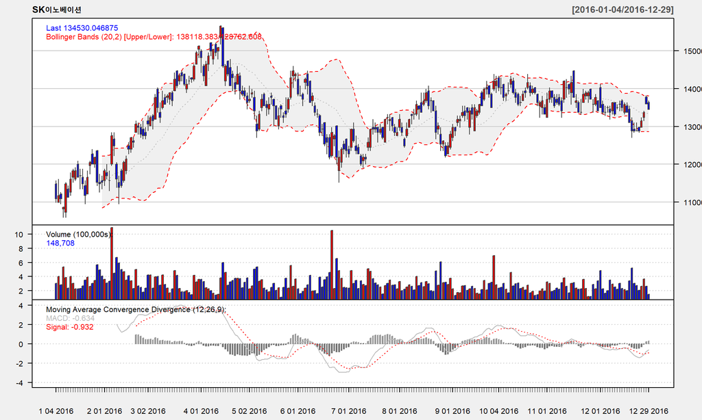

```r
addBBands() #볼린져밴드 추가
```

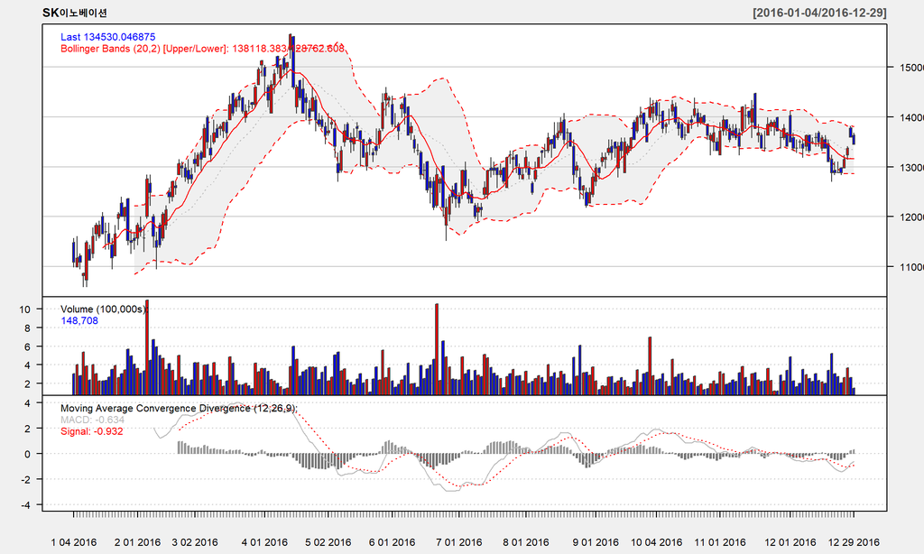

```r
addSMA(10,col='red') #이동평균선 추가
```

### Summary

1. R package `quantmod`
2. `getSymbols()` 함수로 주가정보를 가져오고, 전처리를 할 수 있다.
3. `chartSeries()` 함수로 주가차트를 그리고, 보조지표를 추가 할 수 있다.

### 계획

1. 기업주가 가져오기 : `quantmod`
2. 기업코드 가져오기
3. 모든 기업의 주가가져오기
4. 주가를 이용한 모멘텀 지표만들기
5. 모멘텀 지표로 기업선정하기
6. 재무제표 정보가져오기
7. 재무제표로 우량주 지표를 만들고 기업선정하기
8. 모멘텀지표 + 우량주지표로 기업 선정하기

@ 환율, 경제지표 참조하기